# A Few More Data Wrangling Tools

STAT 331

.larger[A few words about `drop_na()`]

–

- Easy tool to remove missing values

–

- Unilaterally removes **any** row with a missing value for **any** variable

–

- **But** you can specify what columns it should look at for missing values!

.larger[Summarizing Frequencies]

`count()` – counts the values of one or more **categorical** variables

–

```
# A tibble: 49 × 2
   homeworld     n
   <chr>     <int>
 1 Naboo        11
 2 Tatooine     10
 3 <NA>         10
 4 Alderaan      3
 5 Coruscant     3
 6 Kamino        3
 7 Corellia      2
 8 Kashyyyk      2
 9 Mirial        2
10 Ryloth        2
# … with 39 more rows
```

.larger[Unique Groups]

`distinct()` – selects the unique / distinct rows from a dataset

–

.large[**Arguments**]

- `...` – variables to use when determining uniqueness
  - can use multiple!

–

- `.keep_all` – decides if all of the columns should be kept
  - `FALSE` is default!

.larger[Discritizing Variables]

–

- `if_else()`
  - Useful when there are two options

–

- `case_when()`
  - Useful when there are three or more options

.hand[.larger[What if I want to perform the same operation across multiple columns?]]

.larger[`across()`]

> makes it easy to apply the same transformation to multiple columns, allowing you to use `select()` semantics inside in “data-masking” functions like `summarise()` and `mutate()`

–

.large[`across(.cols = everything(), .fns = NULL, ...)`]

`.cols` – columns in data to select  
`.fns` – functions to apply to selected columns  
`...` – addtional arguments for the function calls (from `.fns`)

.larger[Summarizing Multiple Columns]

.large[Conditional Summarizing]

[output not shown]

```
# A tibble: 1 × 3
  height  mass birth_year
   <dbl> <dbl>      <dbl>
1   174.  97.3       87.6
```

.bitlarger[❤️ `|>`]

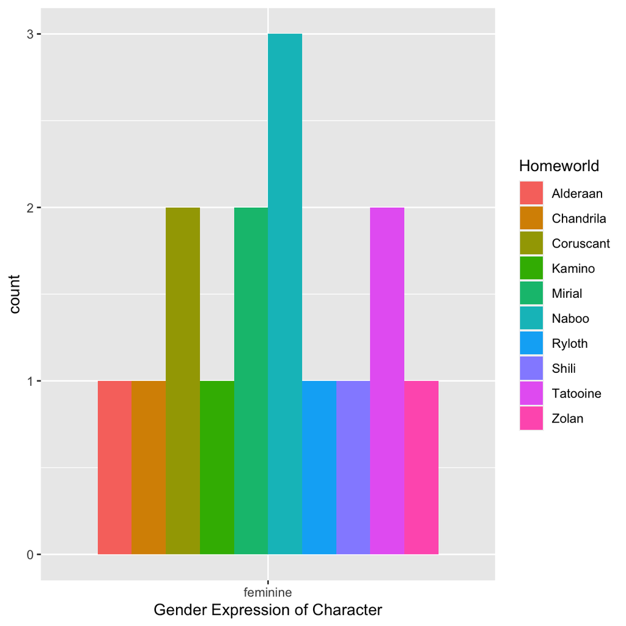

[figure not shown]